# Reproducible Research: Peer Assessment 1

## Loading and preprocessing the data

- Reading data

```r
#Reading data
unzip("activity.zip")
data <- read.csv("./activity.csv")
```

## Question 1: What is mean total number of steps taken per day?

- A histogram of the total number of steps taken per day

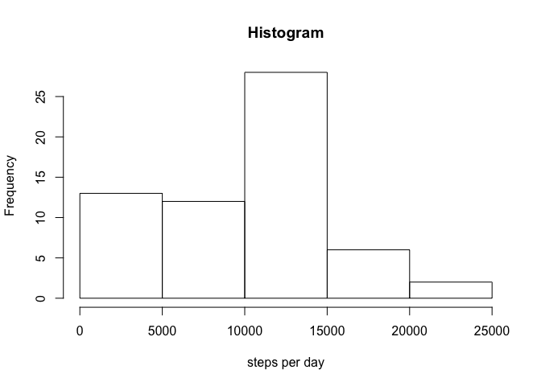

```r
# calculate the steps per day
stepsperday <- tapply(data$steps, data$date, sum, na.rm = T)
# histogram
hist(stepsperday, main = "Histogram", xlab = "steps per day")
```

- The mean number of steps taken per day is 9354.2295082
- The median number is 10395.

```r
mean(stepsperday)
```

```
## [1] 9354.23
```

```r
median(stepsperday)
```

```
## [1] 10395
```

## Question 2: What is the average daily activity pattern?

- Calculating average activity pattern

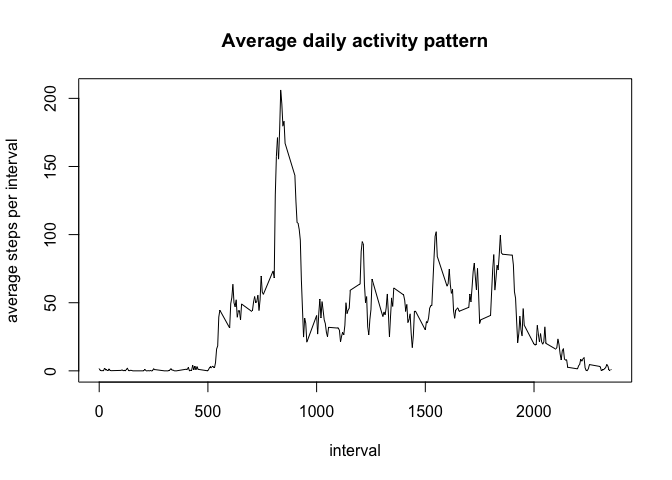

```r
# calculate the average steps per interval
avgsteps<- tapply(data$steps, data$interval, mean, na.rm = T)
# plot average daily activity
plot(levels(as.factor(data$interval)), avgsteps, type = "l", main = "Average daily activity pattern", xlab = "interval", ylab = "average steps per interval")
```

```r
which(avgsteps == max(avgsteps))
```

```
## 835
## 104
```

## Question3: Imputing missing values

- The total number of rows with NAs is 2304.

```r
sum(is.na(data$steps))
```

```
## [1] 2304
```

- Fill in the missing values, by replacing NA values with the median for that interval.

```r
# create a function for replacing NA with median
replaceNAwithMedian <- function(x){
    m <- median(x, na.rm = TRUE)
    x[is.na(x)] <- m
    x
}
```

- Creating a new dataset that is equal to the original dataset but with the missing data filled in.

```r
# replicate data into data1
data1 <- data
# apply the replacing function for steps in each interval
data1$steps <- ave(data$steps, data$interval, FUN = replaceNAwithMedian)
```

- Making a histogram of the total number of steps taken each day and calculating and reporting the mean and median total number of steps taken per day.

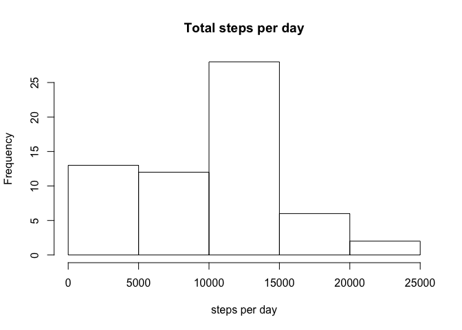

```r
stepsPerDayMedianNA <- tapply(data1$steps, data1$date, sum, na.rm = T)
hist(stepsPerDayMedianNA, main = "Total steps per day", xlab = "steps per day")
```

```r
mean(stepsPerDayMedianNA)
```

```
## [1] 9503.869
```

```r
median(stepsPerDayMedianNA)
```

```
## [1] 10395
```

## Question4: Are there differences in activity patterns between weekdays and weekends?

- Creating a new “weekday” factor variable in the dataset with levels “weekday” and “weekend”.

```r
#converting date format, 0-6 represents Sunday through Saturday
data1$datenew <- as.POSIXlt(data1$date)
data1$weekday <- ifelse(data1$datenew$wday == 0 | data1$datenew$wday == 6, "weekend", "weekday")
```

- Making a time series plot with the 5-minute interval on the x-axis and the average number of steps taken, averaged across all weekday days or weekend days on the y-axis.

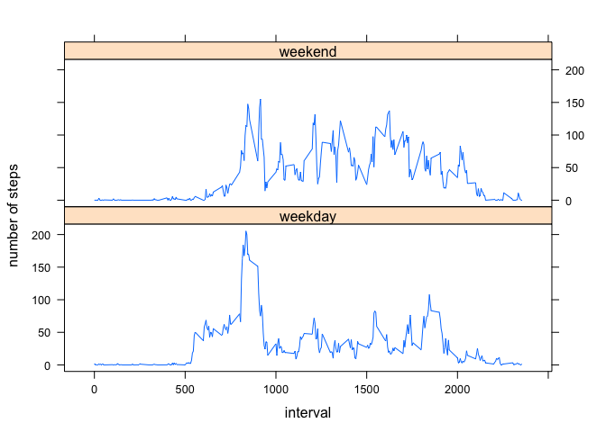

```r
library(lattice)
xyplot(steps ~ interval | weekday, data1, type = "a", layout = c(1, 2), xlab = "interval", ylab = "number of steps", ylim = c(min(avgsteps) - 10, max(avgsteps) + 10))
```